# Lab 3: Instructions

## TBMI26/732A55 Neural Networks and Learning Systems

## Prerequisits

If you want to do the lab assignment on your own machine, you need a CUDA-compatible GPU with Compute Capability >= 3.0 and recent drivers. You also need a Python installation (e.g. Anaconda) based on 3.55 or newer with `keras-gpu` and at least `tensorflow-gpu==1.10`.  
On the machines in Olympen, you enter `module add courses/TBMI26`.

## Jupyter

Start Jupyter `jupyter notebook` and a webbrowser will pop-up. In the webbrowser, you select the catalogue where you have downloaded the matrial for lab 3 (https://liuonline.sharepoint.com/sites/TBMI26/TBMI26_2019VT_L7/CourseDocuments/Assignments) and open the file `Lab3_TBMI26_problems.ipynb`.

## Cells

Jupyter notebooks are structured in cells. Whenever you want to start something new, insert a cell. You can then choose the type of cell in the GUI:

- Ordinary text with formatting is generated by "markdown"
- Code (executable!) is generated by "code" (surprise!). Use "run" in the GUI to run your cell (format the text or execute the code).

## Shortcuts

You can use keyboard shortcuts instead of the GUI to do most/all things. You can run a cell by pressing "shift-return". If you want to change to command mode, press "esc". You get back with "enter". In command mode, you can generate a new cell below ("b") or above ("a"). You delete a cell by pressing "d" twice. You switch to code mode by "y", to markdown mode by "m", and to headings by "1", "2", etc. If you need help with the commands, press "h" in command mode.

## Markdown

In markdown mode, a headline is generated using "#". A sub-headline with "##", etc. Use single `*` or double `**` to write text in *italics* or **bold**. Start a new paragraph by entering two whitespaces before pressing "return". You can generate bullet lists by starting a new line with "* " (note the whitespace) and inline source style using single quotes "`".

## Code

For code, choose "code" or press "y" in command mode. Basically, you can run any Python code.

```python
print("Hello world")
```

```
Hello world
```

Note that a Python notebook is a state machine and thus the context might change if code is re-executed, leading to side effects. If you want to be sure that all context is deleted, run from the "Kernel" menu "Restart & Run All".

## Mathematics and plotting

You can see that the code is directly executed. You can use this to generate interactive documents, containing your text and your code. Even cooler: you can also include mathematics! Try this using LaTeX syntax in the markdown mode and using single `$` (inline) or double `$$` (centered equation). $\mathrm{SoftPlus}(x)=\log(1+\exp(x))$ is a smooth activation function similar to $$\mathrm{ReLU}(x)=\begin{cases}x & x>0\\0 & \text{else}\end{cases}\enspace.$$

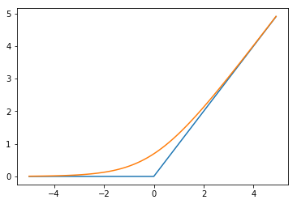

```python
import numpy as np
import matplotlib.pyplot as plt
# this is required if using matplotlib in notebooks:
%matplotlib inline

def relu(x):
    return np.maximum(0,x)

def softplus(x):
    return np.log(1+np.exp(x))

interval_bound = 5
step_size = 0.1
x = np.arange(-interval_bound,interval_bound,step_size)
plt.plot(x,relu(x))
plt.plot(x,softplus(x))
plt.show();
```

## Importing machine learning libraries

We will use Keras as a top-level ML-API and TensorFlow as backend. It is often important to have a sufficiently recent version. We import both libraries and verify their version numbers:

```python
import tensorflow as tf
import keras as k

print('Keras version '+k.__version__+' and TensorFlow version '+tf.__version__)
```

```
Keras version 2.2.4 and TensorFlow version 1.12.0
```

## Reporting your results

There is only one way to report your lab result:

1. You take your finished notebook and run "Restart & Run All". Note that excessive text output (e.g. printing in each learning iteration) should be avoided.
2. You choose under "File" -> "Download as" -> "HTML"
3. You rename your file as "Lab3_TBMI26_liuid1_liuid2.html" where liuid1/2 is the LiU-ID of the two group members
4. You upload your result to Lisam Lab results sent in a different way (other file format, wrong name, not in Lisam) will be ignored.

### Good luck and have fun with the tasks!